# DWEI5_Aula05_HTML-TagsTabelas_CSS-PropriedadesTabelas

Instituto Federal de São Paulo (IFSP)  
[Campus Bragança Paulista/SP](https://bra.ifsp.edu.br)  
**Análise e Desenvolvimento de Sistemas (ADS)**  
**5o. módulo**  
**Profa. Ana Paula Müller Giancoli**  
paulagiancoli@ifsp.edu.br

## AULA 05 - TAGS HTML DE TABELAS E SUAS RESPECTIVAS PROPRIEDADES CSS

### Agenda

- Apresentação das Tags HTML de Tabelas
- Propriedades CCS de Tabelas
- Perguntas

### 1. Apresentação das Tags HTML de Tabelas

- As tags HTML utilizadas para criar uma tabela são:
  - **< table > </ table >**: Indica o início de o fim de uma tabela. Representa dados em duas dimensões ou mais.
  - **< thead > </ thead >**: Representa o cabeçalho da tabela. Neste item, inserimos as tags **< th >, < tr >** combinadas.
  - **< tbody > </ tbody >**: Representa o corpo da tabela. Neste item, inserimos as tags pertinentes para criar o corpo da tabela **< tr >, < td >**.
  - **< tfoot > </ tfoot >**: Representa o rodapé da tabela. Neste item, inserimos as tags **< tr > e < td >** combinadas para indicar informações de rodapé.
- As tags HMTL utilizadas para criar e manter as linhas das tabelas:
  - **< tr > </ tr >**: Representa as linhas de uma tabela.
  - **< th > </ th >**: Representa os títulos das colunas.
  - **< td > </ td >**: Representa os detalhes de cada linha, inseridos dentro de cada < tr >.
  - **< caption > </ caption >**: O elemento HTML < caption > representa o título de uma tabela. Embora ele seja sempre o primeiro filho de um < table >, seu estilo, usando CSS pode colocar ele em qualquer lugar relativo a tabela.
- Os atributos **colspan**, e **rowspan** servem para unir (merge) mais de uma coluna ou linha.
- Exemplos:

  ```
  <td colspan="5">Fonte: (GIANCOLI, 2020) </td>  <!-- Unindo 5 colunas da tabela em uma única célula -->
  <td rowspan="5">Ingredientes: </td>  <!-- Unindo 5 linhas da tabela em uma única célula -->
  ```

- Para aprofundamento do assunto, consulte o [Guia CSS-Tricks](https://css-tricks.com/complete-guide-table-element/).

### 1.1. Exemplo: Estrutura de uma Tabela

```
<!DOCTYPE html>
<html lang="pt-br">
<head>
    <meta charset="UTF-8">
    <title>Exemplo Tags Tabelas</title>
    <link rel="stylesheet" href="css/estilo.css">
</head>
<body>
    <table>
      <caption>Tabela 1: Colunas e Linhas</caption>  <!--- Legenda da Tabela -->
      <thead>  <!--- Cabeçalhos da Tabela -->
        <tr>
          <th>Col-1</th>
          <th>Col-2</th>
          <th>Col-3</th>
          <th>Col-4</th>
          <th>Col-5</th>
        </tr>
      </thead>
      <tbody>  <!--- Corpo da Tabela -->
          <tr>
            <td>Célula 1-L1</td>
            <td>Célula 2-L1</td>
            <td>C3-L1</td>
            <td>C4-L1</td>
            <td>C5-L1</td>
          </tr>
          <tr>
            <td>C1-L2</td>
            <td>C2-L2</td>
            <td>C3-L2</td>
            <td>C4-L2</td>
            <td>C5-L2</td>
          </tr>
          <tr>
            <td>C1-L3</td>
            <td>C2-L3</td>
            <td>C3-L3</td>
            <td>C4-L3</td>
            <td>C5-L3</td>
          </tr>
          <tr>
            <td>C1-L4</td>
            <td>C2-L4</td>
            <td>C3-L4</td>
            <td>C4-L4</td>
            <td>C5-L4</td>
          </tr>
      </tbody>
      <tfoot>  <!--- Rodapé da Tabela -->
          <tr>
            <td colspan="5">Fonte: (GIANCOLI, 2020) </td>
          </tr>
      </tfoot>
    </table>
</body>
</html>
```

- Para alinhar a legenda, utilize a propriedade CSS, **text-align**, e para posicionar a legenda, utilize a propriedade CSS, **caption-side**, podendo ser top, ou bottom.
- As propriedades de fontes e textos podem ser aplicadas às tabelas também.

### 2. Propriedades CSS de Tabelas

### 2.1. Table-layout

- **Valores possíveis** para table-layout:
  - **auto**: um algoritmo de layout de tabela automático é comumente usado pela maioria dos navegadores para layout de tabela. **As larguras da tabela e suas células dependem do seu conteúdo**. Este é o valor padrão.
  - **fixed**: as **larguras da tabela e da coluna** são definidas pelas **larguras dos elementos < table > e < col >** ou pela **largura da primeira linha de células**. **Obs:** Células em linhas subseqüentes não afetam larguras de coluna.

### Fixed

```
<!-- Arquivo index.html -->
<!-- Omitido para facilitar o entendimento -->
<!-- Utilizar a mesma estrutura criada no item 1.1. Exemplo -->
```

```
/* Arquivo estilo.css */
.tabela {
  table-layout: fixed;
  width: 500px;
}
```

**Saída:**

- Utilizando a propriedade **table-layout: fixed;**.

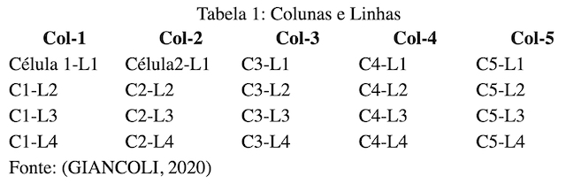

### Auto

```
<!-- Arquivo index.html -->
<!-- Omitido para facilitar o entendimento -->
<!-- Utilizar a mesma estrutura criada no item 1.1. Exemplo -->
```

```
/* Arquivo estilo.css */
.tabela {
  table-layout: auto;
  width: 500px;
}
```

**Saída:**

- Utilizando a propriedade **table-layout: auto;**.

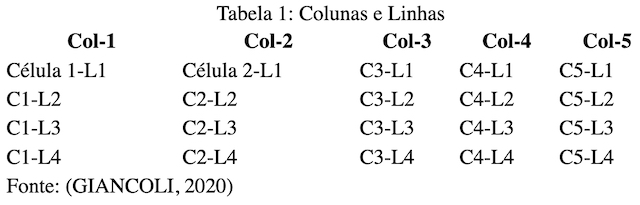

### 2.2. Width

- **width**: controla a largura das colunas. Os valores seguem os padrões definidos em pixels, % etc.

### Pixel

```
<!-- Arquivo index.html -->
<!-- Omitido para facilitar o entendimento -->
<!-- Utilizar a mesma estrutura criada no item 1.1. Exemplo -->
```

```
/* Arquivo estilo.css */
.tabela {
  table-layout: auto;
  width: 500px;
}
```

**Saída:**

- Utilizando a propriedade **width: 500px;**.

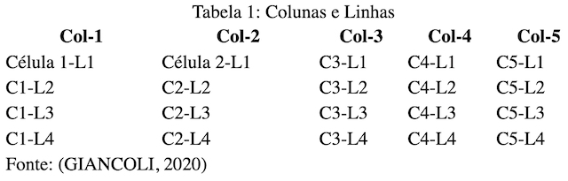

### 2.3. Text-align

- **text-align**: alinha o conteúdo horizontalmente nas células. O valor padrão é à esquerda (left).

### Right

```
<!-- Arquivo index.html -->
<!-- Omitido para facilitar o entendimento -->
<!-- Utilizar a mesma estrutura criada no item 1.1. Exemplo -->
```

```
/* Arquivo estilo.css */
.tabela {
  table-layout: auto;
  width: 500px;
  text-align: right;
}
```

**Saída:**

- Utilizando a propriedade **text-align: right;**.

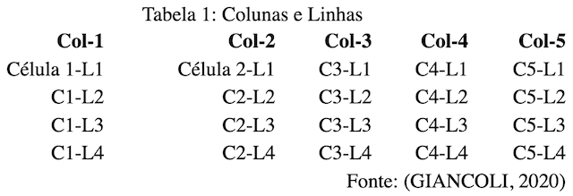

### Center

```
<!-- Arquivo index.html -->
<!-- Omitido para facilitar o entendimento -->
<!-- Utilizar a mesma estrutura criada no item 1.1. Exemplo -->
```

```
/* Arquivo estilo.css */
.tabela {
  table-layout: auto;
  width: 500px;
  text-align: center;
}
```

**Saída:**

- Utilizando a propriedade **text-align: center;**.

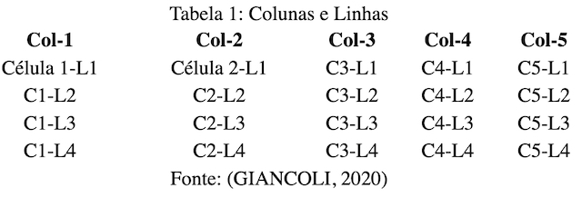

### 2.6. Vertical-align

- **vertical-align**: a propriedade CSS de alinhamento vertical especifica o alinhamento vertical de uma linha.
- **Valores possíveis** para vertical-align:
  - **baseline**: alinha a linha de base do elemento com a linha de base de seu pai.
  - **sub**: Alinha a linha de base do elemento com a linha de base do subscrito de seu pai.
  - **super**: Alinha a linha de base do elemento com a linha de base do superíndice de seu pai.
  - **top**: Alinha a parte superior do elemento com a parte superior da fonte do elemento pai.
  - **bottom**: Alinha a parte inferior do elemento com a parte inferior da fonte do elemento pai.
  - **middle**: Alinha o meio do elemento com a linha de base mais metade da altura x do pai.
- **Para visualizarmos o funcionamento, adicionamos a altura da tabela height: 250px; e em seguida, variamos a propriedade vertical-align com alguns dos valores possíveis**.

### Bottom

```
<!-- Arquivo index.html -->
<!-- Omitido para facilitar o entendimento -->
<!-- Utilizar a mesma estrutura criada no item 1.1. Exemplo -->
```

```
/* Arquivo estilo.css */
.tabela {
  table-layout: auto;
  width: 500px;
  height: 250px;  /* inserido */
  text-align: center;
}
td {
    vertical-align: bottom; /* define um valor padrão para todas as linhas */
}
```

**Saída:**

- Utilizando a propriedade **vertical-align: bottom;**.

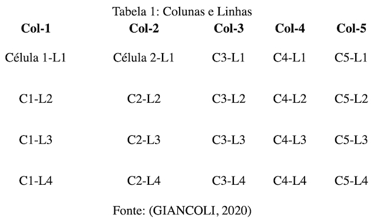

### Top

```
<!-- Arquivo index.html -->
<!-- Omitido para facilitar o entendimento -->
<!-- Utilizar a mesma estrutura criada no item 1.1. Exemplo -->
```

```
/* Arquivo estilo.css */
.tabela {
  table-layout: auto;
  width: 500px;
  height: 250px;  /* inserido */
  text-align: center;
}
td {
    vertical-align: top; /* define um valor padrão para todas as linhas */
}
```

**Saída:**

- Utilizando a propriedade **vertical-align: top;**.

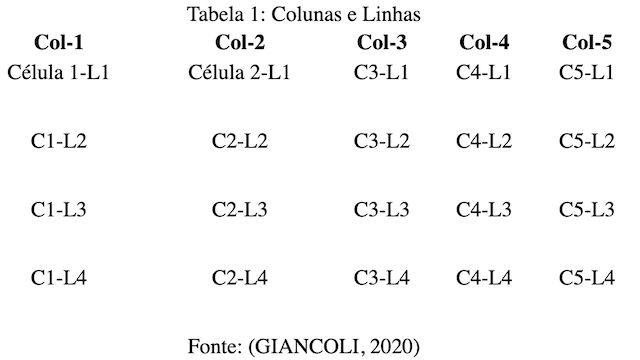

### 2.4 Pseudoclasse :nth-child

- **:nth-child**: configura o alinhamento das células de cada **coluna**.

### :nth-child(valor)

```
<!-- Arquivo index.html -->
<!-- Omitido para facilitar o entendimento -->
<!-- Utilizar a mesma estrutura criada no item 1.1. Exemplo -->
```

```
/* Arquivo estilo.css */
.tabela {
  table-layout: auto;
  width: 500px;
  text-align: center;
}
  /* inserido */
:nth-child(1) {
  text-align: justify;
}
:nth-child(2) {
  text-align: right;
}
:nth-child(3) {
  text-align: left;
}
:nth-child(4) {
  text-align: center;
}
:nth-child(5) {
  text-align: left;
}
```

**Saída:**

- Utilizando a propriedade **:nth-child( )**.

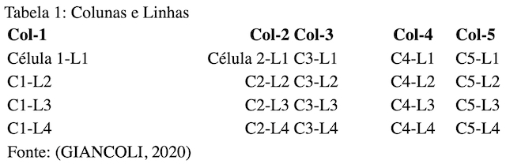

### 2.5. Caption-side

- **caption-side**: a propriedade CSS do lado da legenda posiciona o conteúdo do < caption > de uma tabela no lado especificado.
- **Valores possíveis** para caption-side:
  - Valores direcionais, tais como:
    - **caption-side: top;** Valor padrão.
    - **caption-side: bottom;**.

### Top

```
<!-- Arquivo index.html -->
<!-- Omitido para facilitar o entendimento -->
<!-- Utilizar a mesma estrutura criada no item 1.1. Exemplo -->
```

```
/* Arquivo estilo.css */
.tabela {
  table-layout: auto;
  width: 500px;
  text-align: center;
  caption-side: top;    /* inserido */
}
```

**Saída:**

- Utilizando a propriedade **caption-side: top;**.

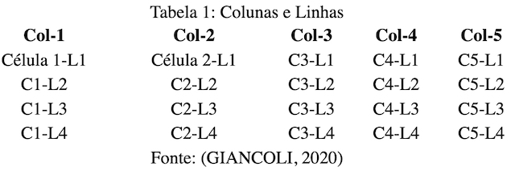

### Bottom

```
<!-- Arquivo index.html -->
<!-- Omitido para facilitar o entendimento -->
<!-- Utilizar a mesma estrutura criada no item 1.1. Exemplo -->
```

```
/* Arquivo estilo.css */
.tabela {
  table-layout: auto;
  width: 500px;
  text-align: center;
  caption-side: bottom;    /* inserido */
}
```

**Saída:**

- Utilizando a propriedade **caption-side: bottom;**.

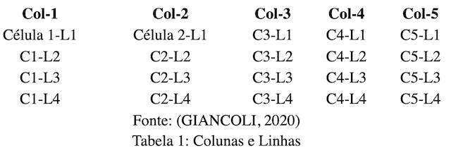

### Dashed

```
<!-- Arquivo index.html -->
<!-- Omitido para facilitar o entendimento -->
<!-- Utilizar a mesma estrutura criada no item 1.1. Exemplo -->
```

```
/* Arquivo estilo.css */
.tabela {
  table-layout: auto;
  width: 500px;
  height: 250px;
  text-align: center;
  border-style: dashed;  /* inserido */
  border-color: red;
}
th {
  border-style: dashed;  /* inserido */
  border-color: #3e8f3e;
}
td {
  vertical-align: middle;
  border-style: dashed;  /* inserido */
  border-color: dodgerblue;
}
```

**Saída:**

- Utilizando a propriedade **border-style: dashed;**.

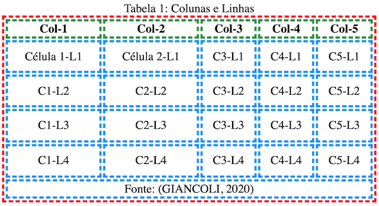

### Solid groove dashed dotted

```
<!-- Arquivo index.html -->
<!-- Omitido para facilitar o entendimento -->
<!-- Utilizar a mesma estrutura criada no item 1.1. Exemplo -->
```

```
/* Arquivo estilo.css */
.tabela {
  table-layout: auto;
  width: 500px;
  height: 250px;
  text-align: center;
  border-style: solid groove dashed dotted;    /* inserido */
  border-color: dodgerblue;
}
td {
  vertical-align: middle;
  border-style: solid;    /* inserido */
  border-color: gray;
}
```

**Saída:**

- Utilizando a propriedade **border-style: solid groove dashed dotted;**. Ao definirmos 4 valores seguidos, a formatação das bordas se dá da seguinte forma: topo, direita, abaixo, esquerda.

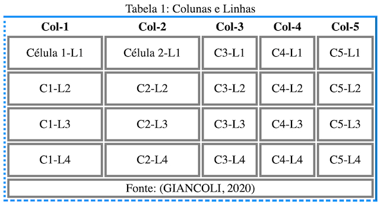

### 2.7. Border-collapse

- **border-collapse**: a propriedade CSS **border-collapse** determina se as bordas de uma tabela **são separadas ou recolhidas**.
- Modelo de borda **separate**:
  - No **modelo de borda separate**, as células adjacentes possuem suas próprias bordas distintas.
  - O **modelo de borda separate é o tradicional modelo de borda de tabela HTML**. A distância entre eles dada pela propriedade **border-spacing**.
- Modelo de borda **collapse**:
  - No **modelo de borda collapse**, as células de tabela adjacentes partilham fronteiras.
- **Valores permitidos**:
  - **separate**: É uma palavra-chave solicitando o uso do modelo de renderização de tabela de borda separada. É o valor padrão.
  - **collapse**: É uma palavra-chave que solicita a utilização do modelo de renderização de tabela de borda recolhida.

### Collapse

```
<!-- Arquivo index.html -->
<!-- Omitido para facilitar o entendimento -->
<!-- Utilizar a mesma estrutura criada no item 1.1. Exemplo -->
```

```
/* Arquivo estilo.css */
.tabela {
  table-layout: auto;
  width: 500px;
  height: 250px;
  text-align: center;
  border-style: solid groove dashed dotted;
  border-color: dodgerblue;
  border-collapse: collapse;
}
td {
  vertical-align: middle;
  border-style: solid;
  border-color: gray;
}
```

**Saída:**

- Utilizando a propriedade **border-collapse: collapse;**.

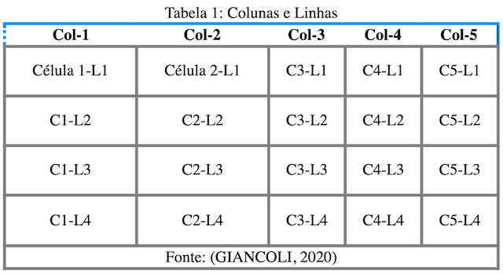

### 2.8. Border-spacing

- **border-spacing**: a propriedade CSS de **espaçamento de bordas** especifica a distância entre as bordas de células de tabela adjacentes (apenas para o modelo de bordas separadas).
- O valor de **espaçamento entre bordas** também é usado ao longo da borda externa da tabela, onde a distância entre a borda da tabela e as células na primeira / última coluna ou linha é a soma do espaçamento entre bordas relevante (horizontal ou vertical) e Relevante (superior, direita, inferior ou esquerda) na tabela.
- *Esta propriedade aplica-se somente quando border-collapse é separate*.
- **Valores possíveis** para border-spacing:
  - **border-spacing: length;**
  - **border-spacing: horizontal vertical;**
  - **border-spacing: inherit;**

### Length

```
<!-- Arquivo index.html -->
<!-- Omitido para facilitar o entendimento -->
<!-- Utilizar a mesma estrutura criada no item 1.1. Exemplo -->
```

```
/* Arquivo estilo.css */
.tabela {
  table-layout: auto;
  width: 500px;
  height: 250px;
  text-align: center;
  border-style: solid;
  border-color: dodgerblue;
  border-collapse: separate;  /* modificado para separte */
  border-spacing: 10px;   /* inserido */
}
td {
  vertical-align: middle;
  border-style: solid;
  border-color: gray;
}
```

**Saída:**

- Utilizando a propriedade **border-spacing: 10px;**.

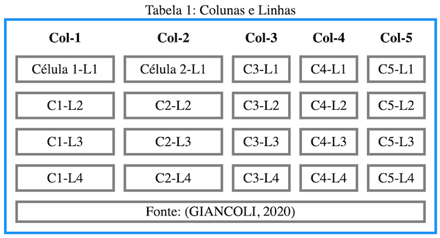

### 2.9. Empty-cells

- **empty-cells**: a propriedade CSS especifica como os agentes de usuário devem renderizar bordas e fundos em torno de células sem conteúdo visível.
- **Valores possíveis** para empty-cells:
  - **show**: É uma palavra-chave que indica que as bordas e fundos devem ser desenhados como em células normais.
  - **hide**: É uma palavra-chave que indica que não há bordas ou fundos a serem desenhados.

### Hide

```
<!-- Arquivo index.html -->
<html>
<!-- Omitido para facilitar o entendimento -->
<body>
    <table class="tabela">
      <caption>Tabela 1: Colunas e Linhas</caption>
      <thead>
        <tr>
          <th>Col-1</th>
          <th></th>   <!-- Conteúdo excluído para exemplificar -->
          <th>Col-3</th>
          <th>Col-4</th>
          <th>Col-5</th>
        </tr>
      </thead>
      <tbody>
          <tr>
            <td>Célula 1-L1</td>
            <td>Célula 2-L1</td>
            <td>C3-L1</td>
            <td></td>   <!-- Conteúdo excluído para exemplificar -->
            <td>C5-L1</td>
          </tr>
          <tr>
            <td>C1-L2</td>
            <td>C2-L2</td>
            <td>C3-L2</td>
            <td>C4-L2</td>
            <td>C5-L2</td>
          </tr>
          <tr>
            <td>C1-L3</td>
            <td></td>   <!-- Conteúdo excluído para exemplificar -->
            <td>C3-L3</td>
            <td>C4-L3</td>
            <td>C5-L3</td>
          </tr>
          <tr>
            <td>C1-L4</td>
            <td>C2-L4</td>
            <td>C3-L4</td>
            <td>C4-L4</td>
            <td>C5-L4</td>
          </tr>
      </tbody>
      <tfoot>
          <tr>
            <td colspan="5">Fonte: (GIANCOLI, 2020) </td>
          </tr>
      </tfoot>
    </table>
</body>
</html>
```

```
/* Arquivo estilo.css */
.tabela {
  table-layout: auto;
  width: 500px;
  height: 250px;
  text-align: center;
  border-style: solid;
  border-color: dodgerblue;
  border-collapse: separate;
  border-spacing: 10px;
}
td {
  vertical-align: middle;
  border-style: solid;
  border-color: gray;
  empty-cells: hide; /* inserido */
}
```

**Saída:**

- Utilizando a propriedade **empty-cells: hide;**.

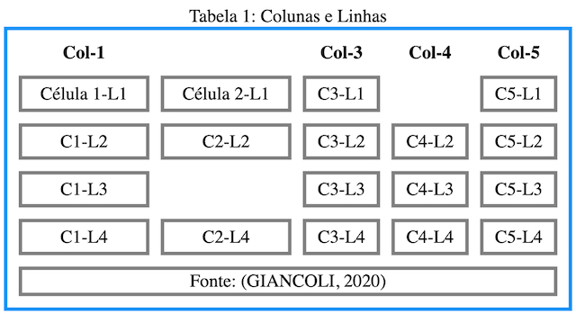

### 2.10 Utilizando Rowspan e Colspan

```
<!-- Arquivo index.html -->
<html>
<!-- Omitido para facilitar o entendimento -->
<body>
    <table class="tabela">
      <caption>Tabela 1: Colunas e Linhas</caption>
      <thead>
        <tr>
          <th>Col-1</th>
          <th>Col-2</th>
          <th>Col-3</th>
          <th>Col-4</th>
          <th>Col-5</th>
        </tr>
      </thead>
      <tbody>
          <tr>
            <td>Célula 1-L1</td>
            <td>Célula 2-L1</td>
            <td>C3-L1</td>
            <td>C4-L1</td>
            <td>C5-L1</td>
          </tr>
          <tr>
            <td rowspan="3">C1-L2</td> <!--  inserido -->
            <td>C2-L2</td>
            <td>C3-L2</td>
            <td>C4-L2</td>
            <td>C5-L2</td>
          </tr>
          <tr>
                                <!-- Excluído pois a Célula C1-L2 ocupou seu espaço -->
            <td>C2-L3</td>
            <td>C3-L3</td>
            <td>C4-L3</td>
            <td>C5-L3</td>
          </tr>
          <tr>
                               <!-- Excluído pois a Célula C1-L2 ocupou seu espaço  -->
            <td>C2-L4</td>
            <td>C3-L4</td>
            <td>C4-L4</td>
            <td>C5-L4</td>
          </tr>
      </tbody>
      <tfoot>
          <tr>
            <td colspan="5">Fonte: (GIANCOLI, 2020) </td>   <!--  inserido -->
          </tr>
      </tfoot>
    </table>
</body>
</html>
```

```
/* Arquivo estilo.css */
.tabela {
  table-layout: auto;
  width: 500px;
  height: 250px;
  text-align: center;
  border-style: solid;
  border-color: dodgerblue;
  border-collapse: separate;
  border-spacing: 10px;
}
td {
  vertical-align: middle;
  border-style: solid;
  border-color: gray;
}
```

**Saída:**

- Utilizando **< td rowspan="3" > C1-L2 < /td >** e **< td colspan="5" > Fonte: (GIANCOLI, 2020) < /td >**.

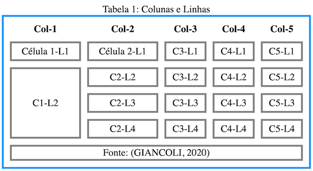

### Referências

- Esta aula foi elaborada a partir do conteúdo disponibilizado em cada um dos links indicados no próprio texto.

### Perguntas

- Esclareça suas eventuais dúvidas durante as aulas.
- Ou pelo *E-mail*: paulagiancoli@ifsp.edu.br.
- Ou pelo *Fórum* do componente curricular.

*ADS - HTML5, CSS3, JS - 5o. módulo*.  
Modelo e formato elaborado por profa. Ana Paula Müller Giancoli - BSD 2-Clause License. - Julho.2021.